# reproducible-vignette

```r
library(SNPfiltR)
library(vcfR)
```

# Optional Step 0:

### Do quality control per sample before performing SNP calling. I have written an [RMarkdown script](https://github.com/DevonDeRaad/RADstackshelpR/blob/master/inst/extdata/fastqcr.Rmd) that uses the R package fastqcr to generate a report visualizing the quality and quantity of sequencing for each sample, and recommending a subset of samples to be immediately dropped before parameter optimization (specifically useful for RADseq data). The only modification necessary for this script is the path to the folder containing the input .fastq.gz files and the path to your desired output folder. An example report generated using this script can be seen [here](https://devonderaad.github.io/RADstackshelpR/articles/quality.control.vignette.html). Because the fastq.gz files for your experiment may be large and handled remotely, an example bash script for executing this RMarkdown file as a job on a high performance computing cluster is available [here](https://github.com/DevonDeRaad/RADstackshelpR/blob/master/inst/extdata/RMarkdown.qc.submit.script.sh).

### Because this is just an example dataset, we will skip this step and load in the vcf and popmap which are distributed with the SNPfiltR package

```r
#load the example vcfR object
data(vcfR.example)

### check the metadata present in your vcf
vcfR.example
```

```
#> ***** Object of Class vcfR *****
#> 20 samples
#> 1 CHROMs
#> 500 variants
#> Object size: 0.7 Mb
#> 38.07 percent missing data
#> *****        *****         *****
```

```r
vcfR.example@fix[1:10,1:8]
```

```
#>       CHROM        POS        ID           REF ALT QUAL FILTER
#>  [1,] "Pseudochr1" "25801497" "16579:67:+" "A" "G" NA   "PASS"
#>  [2,] "Pseudochr1" "25457396" "16292:5:-"  "A" "G" NA   "PASS"
#>  [3,] "Pseudochr1" "20817192" "12868:12:-" "C" "T" NA   "PASS"
#>  [4,] "Pseudochr1" "29813636" "19560:94:+" "T" "C" NA   "PASS"
#>  [5,] "Pseudochr1" "28229092" "18530:62:-" "A" "G" NA   "PASS"
#>  [6,] "Pseudochr1" "9354478"  "4669:39:+"  "C" "T" NA   "PASS"
#>  [7,] "Pseudochr1" "17764465" "10787:26:+" "C" "T" NA   "PASS"
#>  [8,] "Pseudochr1" "5349729"  "1884:88:-"  "A" "T" NA   "PASS"
#>  [9,] "Pseudochr1" "17438085" "10478:65:-" "T" "G" NA   "PASS"
#> [10,] "Pseudochr1" "30854925" "20439:79:+" "G" "T" NA   "PASS"
#>       INFO
#>  [1,] "NS=93;AF=0.059"
#>  [2,] "NS=54;AF=0.056"
#>  [3,] "NS=109;AF=0.037"
#>  [4,] "NS=63;AF=0.016"
#>  [5,] "NS=97;AF=0.433"
#>  [6,] "NS=17;AF=0.059"
#>  [7,] "NS=103;AF=0.330"
#>  [8,] "NS=9;AF=0.111"
#>  [9,] "NS=16;AF=0.469"
#> [10,] "NS=102;AF=0.010"
```

```r
vcfR.example@gt[1:10,1:2]
```

```
#>       FORMAT           A_californica_333849
#>  [1,] "GT:DP:AD:GQ:GL" "0/0:44:44,0:40:-0.00,-14.55,-152.08"
#>  [2,] "GT:DP:AD:GQ:GL" NA
#>  [3,] "GT:DP:AD:GQ:GL" "0/0:347:347,0:40:-0.00,-105.46,-1205.89"
#>  [4,] "GT:DP:AD:GQ:GL" "1/1:3:0,3:16:-9.57,-1.17,-0.03"
#>  [5,] "GT:DP:AD:GQ:GL" "0/1:67:33,34:40:-78.52,0.00,-75.77"
#>  [6,] "GT:DP:AD:GQ:GL" NA
#>  [7,] "GT:DP:AD:GQ:GL" "0/0:331:331,0:40:0.00,-99.80,-1063.41"
#>  [8,] "GT:DP:AD:GQ:GL" NA
#>  [9,] "GT:DP:AD:GQ:GL" NA
#> [10,] "GT:DP:AD:GQ:GL" "0/0:35:35,0:40:-0.00,-12.08,-112.81"
```

```r
#Load the example popmap file. It is a standard two column popmap, where the first column must be named 'id' and contain individual sample identifiers matching the sample identifiers in the vcf file, and the second column must be named 'pop', and contain a population assignment for each sample.
data(popmap)
popmap
```

```
#>                       id          pop
#> 1   A_californica_333849  californica
#> 2   A_californica_333854  californica
#> 3   A_californica_333855  californica
#> 4   A_californica_333857  californica
#> 5   A_californica_333860  californica
#> 6     A_insularis_334031    insularis
#> 7     A_insularis_334032    insularis
#> 8     A_insularis_334033    insularis
#> 9     A_insularis_334034    insularis
#> 10    A_insularis_334037    insularis
#> 11  A_woodhouseii_334133  woodhouseii
#> 12  A_woodhouseii_334134  woodhouseii
#> 13  A_woodhouseii_334142  woodhouseii
#> 14  A_woodhouseii_334148  woodhouseii
#> 15  A_woodhouseii_334153  woodhouseii
#> 16 A_coerulescens_396256 coerulescens
#> 17 A_coerulescens_396259 coerulescens
#> 18 A_coerulescens_396262 coerulescens
#> 19 A_coerulescens_396263 coerulescens
#> 20 A_coerulescens_396264 coerulescens
```

### step 1: Implement quality filters that don’t involve missing data. This is because removing low data samples will alter percentage/quantile based missing data cutoffs, so we wait to implement those until after deciding on our final set of samples for downstream analysis

```r
#generate exploratory visualizations of depth and genotype quality for all called genotypes
#hard_filter(vcfR=vcfR.example)

#hard filter to minimum depth of 5, and minimum genotype quality of 30
vcfR<-hard_filter(vcfR=vcfR.example, depth = 5, gq = 30)
```

```
#> [1] "28.81% of genotypes fall below a read depth of 5 and were converted to NA"
#> [1] "3.81% of genotypes fall below a genotype quality of 30 and were converted to NA"
```

### Use this function to filter for allele balance from Puritz SNP filtering tutorial “Allele balance: a number between 0 and 1 representing the ratio of reads showing the reference allele to all reads, considering only reads from individuals called as heterozygous, we expect that the allele balance in our data (for real loci) should be close to 0.5”

```r
#execute allele balance filter
vcfR<-filter_allele_balance(vcfR)
```

```
#> [1] "7.54% of het genotypes (0.71% of all genotypes) fall outside of .25 - .75 allele balance and were converted to NA"
```

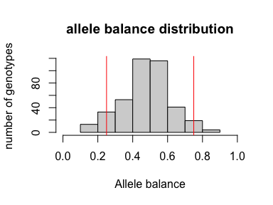

### max depth filter (super high depth loci are likely multiple loci stuck together into a single paralogous locus).

```
#> [1] "maxdepth cutoff is specified, filtered vcfR object will be returned"
```

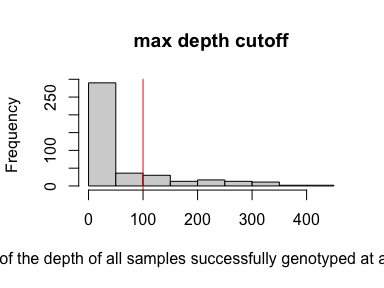

[output not shown]

```r
#visualize and pick appropriate max depth cutoff
#max_depth(vcfR)
#not running here to save space on visualizations

#reset plotting window
par(mfrow = c(1,1))

#filter vcf by the max depth cutoff you chose
vcfR<-max_depth(vcfR, maxdepth = 100)
```

### Step 2: visualize missing data by sample. Check out the visualizations and make decision on which samples look like they will not be salvageable for downstream analysis.

```r
#run function to visualize samples and return informative data.frame object
miss<-missing_by_sample(vcfR=vcfR)
```

```
#> [1] "No popmap provided"
```

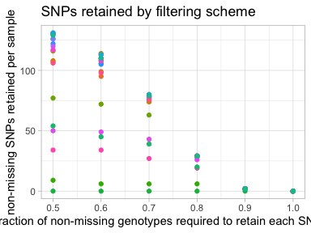

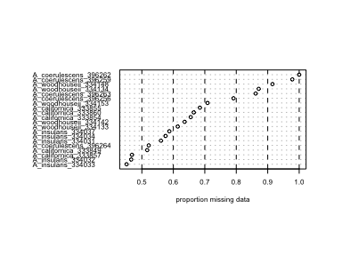

```r
#run function to drop samples above the threshold we want from the vcf
#here I am setting a relatively lax cutoff
vcfR<-missing_by_sample(vcfR=vcfR, cutoff = .9)
```

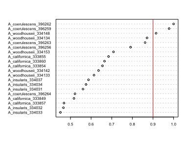

```
#> [1] "3 samples are above a 0.9 missing data cutoff, and were removed from VCF"

#remove invariant sites generated by sample trimming and genotype filtering
vcfR<-min_mac(vcfR, min.mac = 1)
```

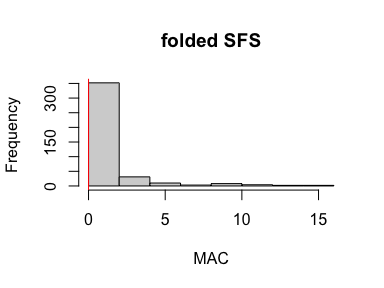

```
#> [1] "51.94% of SNPs fell below a minor allele count of 1 and were removed from the VCF"

#update popmap by removing samples that have been filtered out
popmap<-popmap[popmap$id %in% colnames(vcfR@gt)[-1],]
```

### Step 3: Set the arbitrary missing data cutoff

### We can visualize the effect that typical missing data cutoffs will have on both the number of SNPs retained and the total missing data in our entire dataset. We want to choose a cutoff that minimizes the overall missing data in the dataset, while maximizing the total number of loci retained.

```r
#visualize missing data by SNP and the effect of various cutoffs on the missingness of each sample
missing_by_snp(vcfR)
```

```
#> [1] "cutoff is not specified, exploratory visualizations will be generated"
```

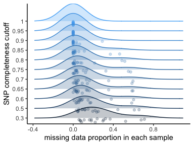

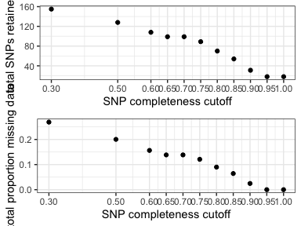

```
#>    filt missingness snps.retained
#> 1  0.30  0.26907021           155
#> 2  0.50  0.20036765           128
#> 3  0.60  0.15631808           108
#> 4  0.65  0.13844326            99
#> 5  0.70  0.13844326            99
#> 6  0.75  0.12095175            89
#> 7  0.80  0.08991597            70
#> 8  0.85  0.06427015            54
#> 9  0.90  0.02466793            31
#> 10 0.95  0.00000000            18
#> 11 1.00  0.00000000            18
```

### we can see that there are still some outlier samples with a lot of missing data even at high missing data per SNP thresholds

#we can check whether this excess missing data in some samples is affecting overall clustering patterns

```r
#assess missing data effects on clustering
assess_missing_data_pca(vcfR = vcfR, popmap = popmap, thresholds = c(.8), clustering = FALSE)
```

```
#> [1] "cutoff is specified, filtered vcfR object will be returned"
#> [1] "64.65% of SNPs fell below a completeness cutoff of 0.8 and were removed from the VCF"
```

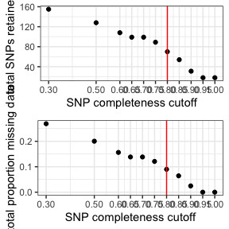

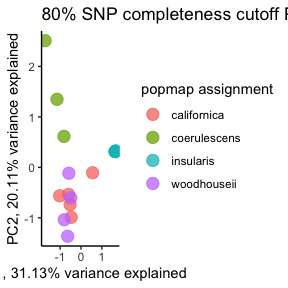

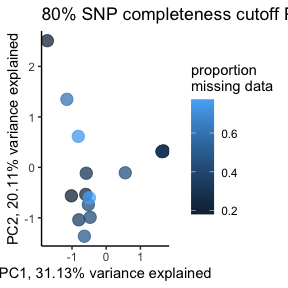

```
#> [[1]]
#>                              PC1        PC2          PC3         PC4
#> A_californica_333849  -0.5969622 -0.5362690 -0.595508158  0.73945078
#> A_californica_333854  -0.4693982 -0.9890245 -1.414869592 -1.37005171
#> A_californica_333855   0.5581980 -0.1075819 -0.257991833  0.14855832
#> A_californica_333857  -1.0182608 -0.5641853 -0.417897234 -0.28592615
#> A_californica_333860  -0.5224670 -0.7392822 -0.823298194 -0.01861634
#> A_insularis_334031     1.6356477  0.3136035  0.074824184 -0.03538247
#> A_insularis_334032     1.6717696  0.3245417  0.079829224 -0.03590089
#> A_insularis_334033     1.6695981  0.3219187  0.075663814 -0.03325062
#> A_insularis_334034     1.6356477  0.3136035  0.074824184 -0.03538247
#> A_insularis_334037     1.6356477  0.3136035  0.074824184 -0.03538247
#> A_woodhouseii_334133  -0.5830285 -0.1164268 -0.007498313  0.86818251
#> A_woodhouseii_334134  -0.4918528 -0.6028390  0.150783442  0.31303844
#> A_woodhouseii_334142  -0.8005397 -1.0392687  0.531437285  1.20318761
#> A_woodhouseii_334153  -0.6375918 -1.3648416  2.046665190 -1.05594446
#> A_coerulescens_396256 -1.1495480  1.3483650  0.060491990  0.14644120
#> A_coerulescens_396263 -0.8159388  0.6141574  0.121397651 -0.06714767
#> A_coerulescens_396264 -1.7209210  2.5099257  0.226322176 -0.44587363
#>                               PC5          PC6          pop   missing
#> A_californica_333849   1.34940006 -0.217111195  californica 0.2272727
#> A_californica_333854  -0.31732671 -0.252236192  californica 0.4343434
#> A_californica_333855   0.79002290 -0.411529451  californica 0.4545455
#> A_californica_333857  -0.27279109 -0.675313989  californica 0.1818182
#> A_californica_333860  -0.29414891  1.230546314  californica 0.4343434
#> A_insularis_334031    -0.11699427  0.010904247    insularis 0.2929293
#> A_insularis_334032    -0.12438335  0.006458987    insularis 0.1919192
#> A_insularis_334033    -0.11649650 -0.001424441    insularis 0.1818182
#> A_insularis_334034    -0.11699427  0.010904247    insularis 0.3535354
#> A_insularis_334037    -0.11699427  0.010904247    insularis 0.3383838
#> A_woodhouseii_334133   0.22400118  0.462404897  woodhouseii 0.3181818
#> A_woodhouseii_334134  -0.05571374  0.543962142  woodhouseii 0.7727273
#> A_woodhouseii_334142  -1.18389174 -0.521504387  woodhouseii 0.3686869
#> A_woodhouseii_334153   0.44668940  0.174951057  woodhouseii 0.4898990
#> A_coerulescens_396256  0.01905756  0.014972030 coerulescens 0.6111111
#> A_coerulescens_396263  0.03051154 -0.599271664 coerulescens 0.7424242
#> A_coerulescens_396264 -0.14394778  0.212383154 coerulescens 0.2070707
```

### we can see that at an 80% per SNP completeness cutoff, samples with an excess of missing data are leaking toward the center (specifically coerulescens samples), indicating that they can’t be reliably clustered due to excess missing data

### This means we still need to target specific samples with too much missing data even at high filtering thresholds, for removal

```r
#show me the samples with the most missing data at an 80% completeness threshold
filt<-miss[miss$filt == .8,]
filt[order(filt$snps.retained),]
```

[output not shown]

```r
#drop the three samples with an excess of missing data at an 80% SNP completeness threshold
vcfR<- vcfR[,colnames(vcfR@gt) != "A_coerulescens_396263" & colnames(vcfR@gt) != "A_woodhouseii_334134" & colnames(vcfR@gt) != "A_coerulescens_396256"]

#remove invariant SNPs
vcfR<-min_mac(vcfR, min.mac = 1)
```

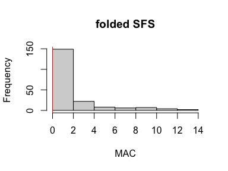

```
#> [1] "3.54% of SNPs fell below a minor allele count of 1 and were removed from the VCF"
vcfR
#> ***** Object of Class vcfR *****
#> 14 samples
#> 1 CHROMs
#> 191 variants
#> Object size: 0.2 Mb
#> 31.71 percent missing data
#> *****        *****         *****

#update popmap by removing samples that have been filtered out
popmap<-popmap[popmap$id %in% colnames(vcfR@gt)[-1],]
```

### re-visualize missing data by SNP and the effect of various cutoffs on the missingness of each sample and set a reasonable missing data cutoff

```r
missing_by_snp(vcfR)
```

```
#> [1] "cutoff is not specified, exploratory visualizations will be generated"
```

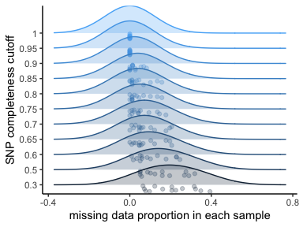

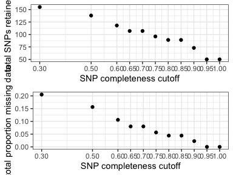

```
#>    filt missingness snps.retained
#> 1  0.30  0.20506912           155
#> 2  0.50  0.15631470           138
#> 3  0.60  0.10593220           118
#> 4  0.65  0.08010681           107
#> 5  0.70  0.08010681           107
#> 6  0.75  0.05654762            96
#> 7  0.80  0.04414125            89
#> 8  0.85  0.04414125            89
#> 9  0.90  0.02250489            73
#> 10 0.95  0.00000000            50
#> 11 1.00  0.00000000            50
#all samples look good at most thresholds, because of the small size of this dataset, I will choose a 60% completeness threshold in order to retain as many SNPs as possible

#filter vcfR
vcfR<-missing_by_snp(vcfR, cutoff = .6)
#> [1] "cutoff is specified, filtered vcfR object will be returned"
```

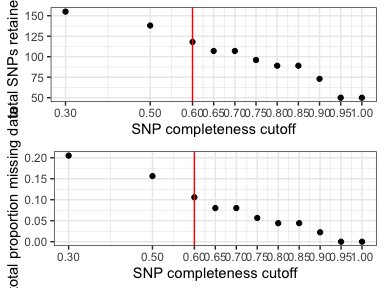

```
#> [1] "38.22% of SNPs fell below a completeness cutoff of 0.6 and were removed from the VCF"

#look at final stats for our filtered vcf file
vcfR
#> ***** Object of Class vcfR *****
#> 14 samples
#> 1 CHROMs
#> 118 variants
#> Object size: 0.2 Mb
#> 10.59 percent missing data
#> *****        *****         *****
```

### We can now use the convenient function vcfR::write.vcf() to export our filtered vcf file for downstream analyses

### Note: the function vcfR::write.vcf() automatically writes a gzipped vcf file, so be sure to add the suffix .gz to the name of your output file.

```r
#write out vcf
vcfR::write.vcf(vcfR, file = "~/Downloads/scrub.jay.example.filtered.vcf.gz")
```